# Wrangle act

## Introduction

WeRateDogs is a Twitter account that rates people's dogs with a humorous comment about the dog. The account was started in 2015 by college student Matt Nelson, and has received international media attention both for its popularity and for the attention drawn to social media copyright law when it was suspended by Twitter for breaking these aforementioned laws.

We rate dogs right now have 8.8 million follower in twitter.

The data was provided from udacity and I just explore it to answer these question.

- What is the top 10 used name?
- What is the most dog type ?
- What is rating for these dogs in the dataset?
- What is the percantage of retweet and favorite for these dogs?
- What is the highest retweet tweet in the dataset?
- What is the highest favorite tweet in the dataset?

## 1) What is the top 10 used name?

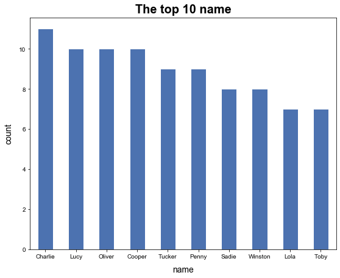

**Observation:** As is shown the bar chart, the most used name was Charlie with 11.Then come in the second place Lucy, Oliver and Cooper. Then in the 4th place Tucker and Penny. Then the 6th place Sadie and Winston. Finally in the 9th place Lola and Toby.

## 2) What is the most dog type ?

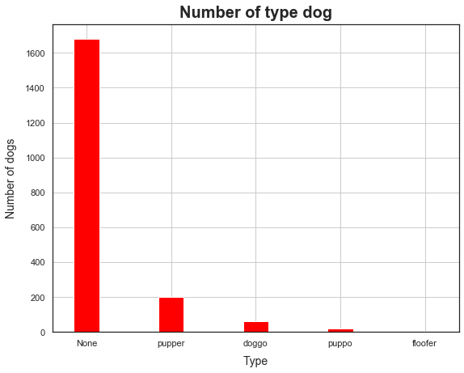

**Observation:** As is shown the bar chart, most of the dogs are unknown could be different type or not registered. But for the types we already known in the fisrt place is pupper. Then came in the second place doggo. In the third place came Puppo and finally come floofer.

## 3) What is rating for these dogs in the dataset?

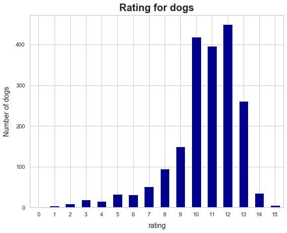

**Observation:** As is shown the bar chart, most of the dogs rated with 12.

## 4) What is the percantage of retweet and favorite for these dogs?

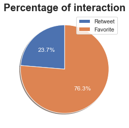

**Observation:** As is shown the pie chart, most of the users used favorite rather than retween considering that the user can use both of them in one tweet.

## 5) What is the highest retweet tweet in the dataset?

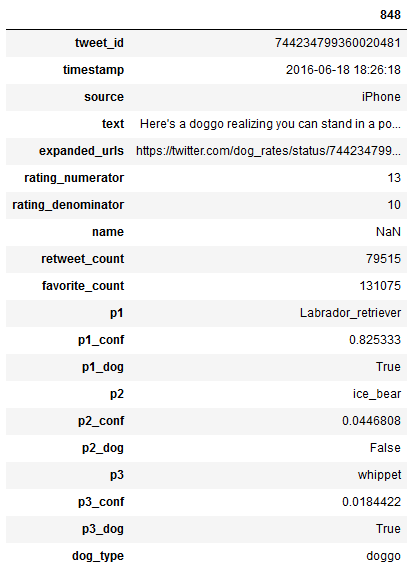

**Observation:** As is shown result,the most tweet have retweet was (744234799360020481) and that tweet came from iPhone and have rating 13 and the dog type was doggo with 79515 retweet and 131075 favorite.

## 6) What is the highest favorite tweet in the dataset?

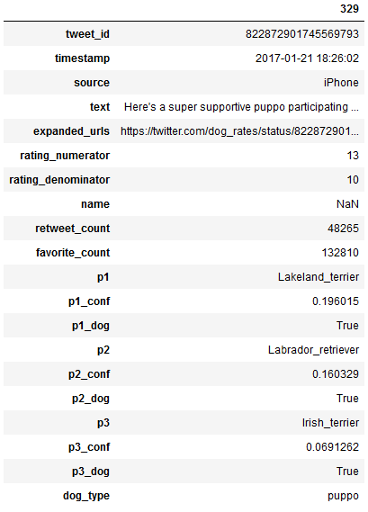

**Observation:** As is shown result,the most tweet have favorite was (822872901745569793) and that tweet came from iPhone and have rating 13 and the dog type was puppo with 48265 retweet and 132810 favorite.

## Insights

- The most used name was 'Charlie'
- The most type registered in dataset was 'pupper'
- Most of the dogs get rated '12'
- The highest rewteet tweet got 79515 retweet
- The highest favorite tweet got 132810 favorite